# Introduction to Statistical Inference

Dr. Gwen Eadie

November 4, 2019

## Linear Regression

```r
# make a vector that represents the response variable
y = c(13,15,9,17,8,5,19,23,10,7,10,6)

# make two vectors of predictor variables
x1 = c(1,1,1,1,1,1,rep(0,6)) # this is a binary predictor. Check: what is the function rep() doing here?
x2 = c(1,1,1,1,2,2,2,2,3,3,3,3)

# now do a linear regression of y on x1 and x2, and save the output to an object called mymodel
mymodel = lm(y ~ x1 + x2)

# get the coefficients on the predictors and the intercept
print(mymodel)
```

```
##
## Call:
## lm(formula = y ~ x1 + x2)
##
## Coefficients:
## (Intercept)           x1           x2
##      38.833      -14.500       -9.875
```

```r
# the R summary function can be used for all types of classes in R. What does it show you about mymodel? Run the following line in R to find out
summary(mymodel)
```

```
##
## Call:
## lm(formula = y ~ x1 + x2)
##
## Residuals:
##     Min      1Q  Median      3Q     Max
## -5.4583 -1.6458  0.4792  1.2292  3.9167
##
## Coefficients:
##             Estimate Std. Error t value Pr(>|t|)
## (Intercept)   38.833      5.090   7.630 3.23e-05 ***
## x1           -14.500      3.024  -4.795 0.000980 ***
## x2            -9.875      1.852  -5.333 0.000473 ***
## ---
## Signif. codes:  0 '***' 0.001 '**' 0.01 '*' 0.05 '.' 0.1 ' ' 1
##
## Residual standard error: 3.024 on 9 degrees of freedom
## Multiple R-squared:  0.7633, Adjusted R-squared:  0.7107
## F-statistic: 14.51 on 2 and 9 DF,  p-value: 0.001527
```

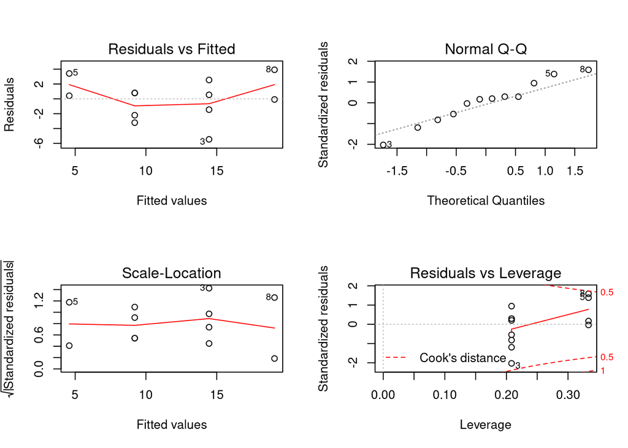

```r
par(mfrow=c(2,2)) # make a 2 x 2 plot
# plot the four default diagnostic plots provided by plot when it is passed an lm object
plot(mymodel)
```

## Sampling a Random Variable in the Computer

The Pareto distribution has the following probability density function:
$$f(x)=\frac{\alpha x_{\mathrm{min}}^{\alpha}}{x^{\alpha+1}}$$
where $x_{\mathrm{min}}>0$ and $\alpha>0$ are parameters, and $x\geq x_{\mathrm{min}}$.

The cumulative distribution function is:
$$F(x)=P(X\leq x)=1-\left(\frac{x_{\mathrm{min}}}{x}\right)^{\alpha}$$
.

1. In R, write a function for the inverse cumulative Pareto distribution function. Your function should accept a probability $p$ as well as parameters $x_{\mathrm{min}}$ and $\alpha$. Given these inputs, your function should return a value for $x$.
2. Using the function you defined in part 1., generate 100 draws from the Pareto distribution with parameters $x_{\mathrm{min}}=2$ and $\alpha=3$. Does the distribution of your 100 draws appear to match the Pareto density?

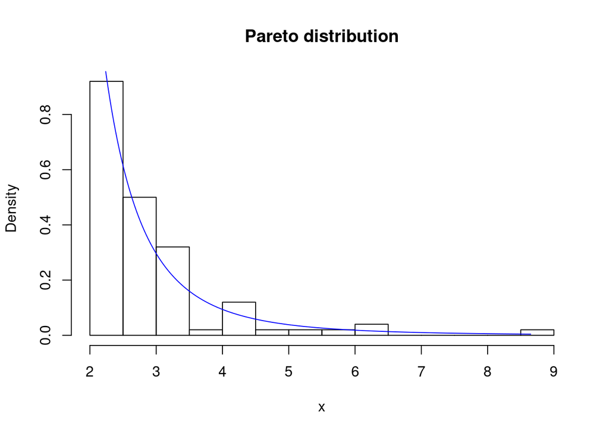

```r
# The inverse Pareto distribution
invPareto <- function( p, xmin, alpha ) xmin/((1-p)^(1/alpha))
# Function to generate random draws
rPareto <- function( n, xmin, alpha ) invPareto( runif(n), xmin, alpha )
# Generate 100 draws
x <- rPareto( 100, 2, 3 )
# Plot and compare to Pareto density
dPareto <- function( x, xmin, alpha ) (alpha*xmin^alpha)/(x^(alpha+1))
hist( x , xlab = "x", main = "Pareto distribution", freq = FALSE, breaks = 12 )
lines( seq( 2, max(x), 0.01 ), dPareto( seq( 2, max(x), 0.01 ), 2, 3 )
     , col = "blue" )
```

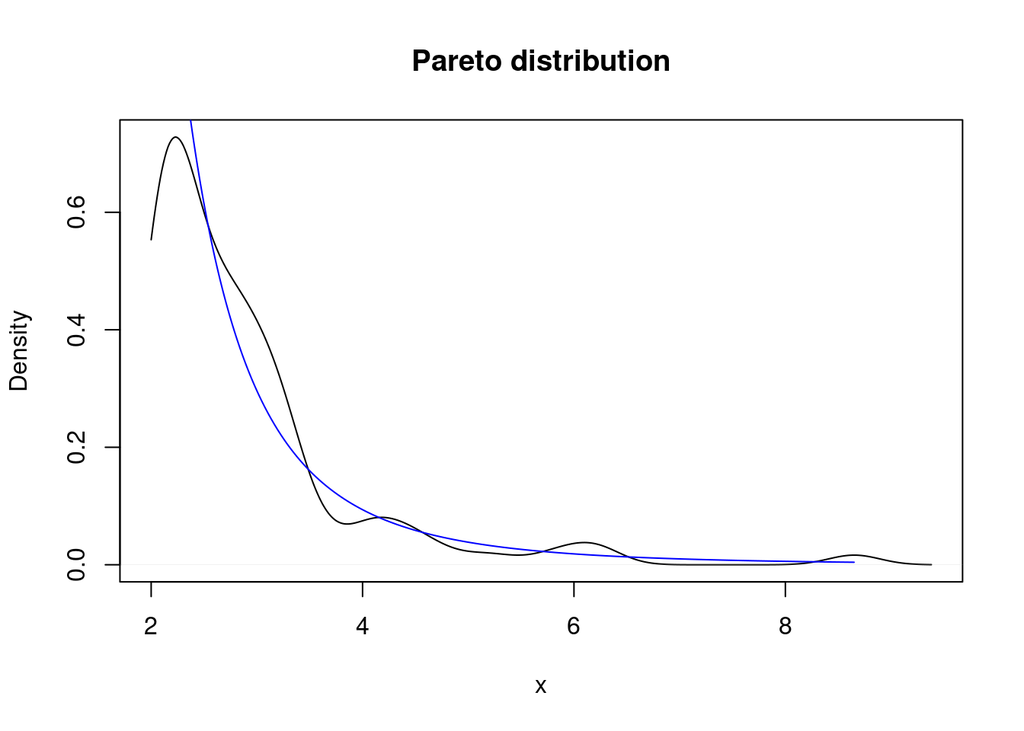

```r
plot( density( x, from = 2 ), xlab = "x", main = "Pareto distribution" )
lines( seq( 2, max(x), 0.01 ), dPareto( seq( 2, max(x), 0.01 ), 2, 3 )
     , col = "blue" )
```

## Linear Regression: Errors in Variables

```r
hyades <- readRDS( "hyades.rsv" )
```

1. Fit a line to the log-luminosity versus colour index. That is, fit the line `lm( logL ~ B_V, data = hyades )`. What are the estimates of the regression coefficients $\beta_{0}$ and $\beta_{\mathrm{B-V}}$? Make a plot of the data and the line fit if you like (you can use `abline` for this!).

```r
fit1 <- lm( logL ~ B_V, data = hyades )
summary( fit1 )
```

```
##
## Call:
## lm(formula = logL ~ B_V, data = hyades)
##
## Residuals:
##      Min       1Q   Median       3Q      Max
## -0.21126 -0.11934 -0.03627  0.07812  0.60282
##
## Coefficients:
##             Estimate Std. Error t value Pr(>|t|)
## (Intercept)  1.77942    0.03583   49.66   <2e-16 ***
## B_V         -2.36162    0.05325  -44.35   <2e-16 ***
## ---
## Signif. codes:  0 '***' 0.001 '**' 0.01 '*' 0.05 '.' 0.1 ' ' 1
##
## Residual standard error: 0.1565 on 86 degrees of freedom
## Multiple R-squared:  0.9581, Adjusted R-squared:  0.9576
## F-statistic:  1967 on 1 and 86 DF,  p-value: < 2.2e-16
```

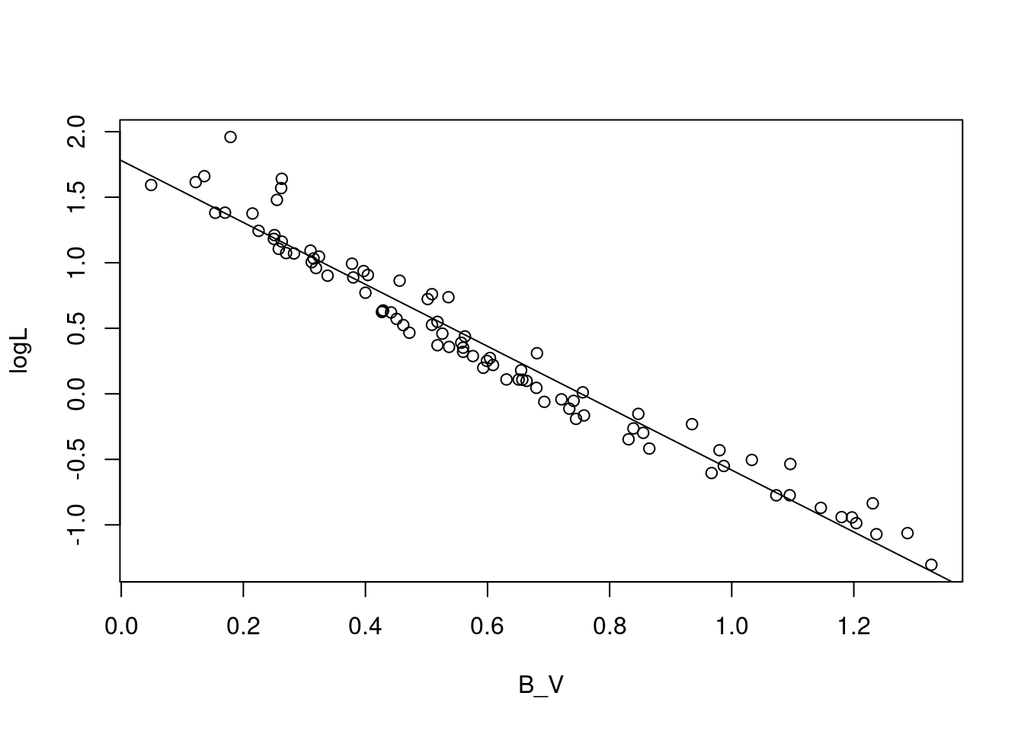

```r
plot( logL ~ B_V, data = hyades )
abline( fit1 )
```

2. What happens to your estimates of $\beta_{0}$ and $\beta_{\mathrm{B-V}}$ when additional measurement error is added to the colour index data? Add Normally distributed measurement error to the colour index data and re-fit the regression.

```r
hyades$B_V2 <- rnorm( nrow(hyades), hyades$B_V, 0.1 )
fit2 <- lm( logL ~ B_V2, data = hyades )
summary( fit2 )
```

```
##
## Call:
## lm(formula = logL ~ B_V2, data = hyades)
##
## Residuals:
##      Min       1Q   Median       3Q      Max
## -0.44543 -0.18631 -0.04626  0.17619  0.95090
##
## Coefficients:
##             Estimate Std. Error t value Pr(>|t|)
## (Intercept)  1.61524    0.05876   27.49   <2e-16 ***
## B_V2        -2.08459    0.08572  -24.32   <2e-16 ***
## ---
## Signif. codes:  0 '***' 0.001 '**' 0.01 '*' 0.05 '.' 0.1 ' ' 1
##
## Residual standard error: 0.2725 on 86 degrees of freedom
## Multiple R-squared:  0.873,  Adjusted R-squared:  0.8716
## F-statistic: 591.3 on 1 and 86 DF,  p-value: < 2.2e-16
```

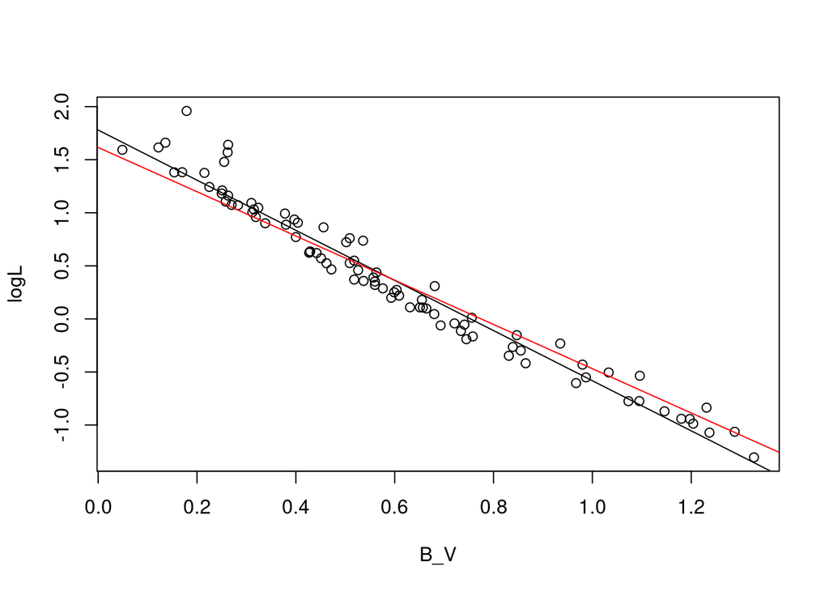

```r
plot( logL ~ B_V, data = hyades )
abline( fit1 )
abline( fit2, col = 2 )
```

3. Try different values for the standard deviation of the measurement error in colour index. Does the effect on $\beta_{0}$ and $\beta_{\mathrm{B-V}}$ change? How? What does this suggest for the existing coefficients from question 1?

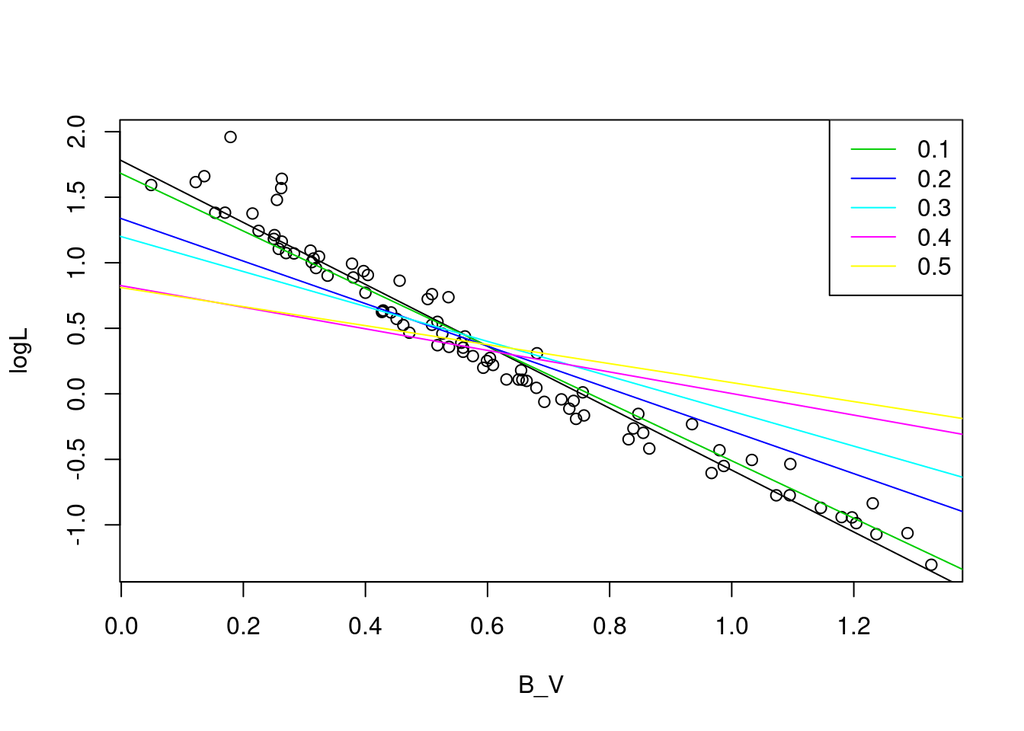

```r
plot( logL ~ B_V, data = hyades )
abline( fit1 )
s <- seq(0.1,0.5,0.1)
for( i in 1:length(s) ){
  B_Verr <- rnorm( nrow(hyades), hyades$B_V, s[i] )
  fit <- lm( hyades$logL ~ B_Verr )
  abline( fit, col = i+2 )
}
legend( "topright", legend = as.character(s), col = (1:length(s))+2, lty = 1 )
```